# Lab 3. Exploratory Data Analysis

Faith Okaalo

2026-01-29

```r
library (tidyverse)
```

```r
library (leaflet)
library (corrplot)
```

# Step 1: Read in the data.

```r
met <- read.csv("C:/Users/faith/Downloads/met_all.gz")
```

# Step 2: Check the dimensions, headers, footers

```r
dim(met)
```

```
## [1] 2377343      30
```

## The met dataset has a total of 2,377,343 observations and 30 variables

# Step 3: Take a look at all the variables

```r
str(met)
```

```
## 'data.frame':    2377343 obs. of  30 variables:
##  $ USAFID           : int  690150 690150 690150 690150 690150 690150 690150 690150 690150 690150 ...
##  $ WBAN             : int  93121 93121 93121 93121 93121 93121 93121 93121 93121 93121 ...
##  $ year             : int  2019 2019 2019 2019 2019 2019 2019 2019 2019 2019 ...
##  $ month            : int  8 8 8 8 8 8 8 8 8 8 ...
##  $ day              : int  1 1 1 1 1 1 1 1 1 1 ...
##  $ hour             : int  0 1 2 3 4 5 6 7 8 9 ...
##  $ min              : int  56 56 56 56 56 56 56 56 56 56 ...
##  $ lat              : num  34.3 34.3 34.3 34.3 34.3 34.3 34.3 34.3 34.3 34.3 ...
##  $ lon              : num  -116 -116 -116 -116 -116 ...
##  $ elev             : int  696 696 696 696 696 696 696 696 696 696 ...
##  $ wind.dir         : int  220 230 230 210 120 NA 320 10 320 350 ...
##  $ wind.dir.qc      : chr  "5" "5" "5" "5" ...
##  $ wind.type.code   : chr  "N" "N" "N" "N" ...
##  $ wind.sp          : num  5.7 8.2 6.7 5.1 2.1 0 1.5 2.1 2.6 1.5 ...
```

[output cut: 16 more lines]

# Most of the variables seem to be appropriately stored. Measurement variables such as temperature, wind speed, relative humidity, and atmospheric pressure are stored as numeric or integer types, while quality control and code variables are stored as character or integer values. I noticed that station identifier variables (USAFID and WBAN) are stored as integers, although they may just be identifiers rather than quantities and may be better stored as character variables instead.

# Step 4: Take a closer look at the key variables (year, day, hour, temp, elev, wind.sp). Hint: use table and/or summary)

```r
# Year
table(met$year)
```

```
##
##    2019
## 2377343
```

```r
# day
table(met$day)
```

```
##
##     1     2     3     4     5     6     7     8     9    10    11    12    13
## 75975 75923 76915 76594 76332 76734 77677 77766 75366 75450 76187 75052 76906
##    14    15    16    17    18    19    20    21    22    23    24    25    26
## 77852 76217 78015 78219 79191 76709 75527 75786 78312 77413 76965 76806 79114
##    27    28    29    30    31
## 79789 77059 71712 74931 74849
```

```r
#hour
table(met$hour)
```

```
##
##      0      1      2      3      4      5      6      7      8      9     10
##  99434  93482  93770  96703 110504 112128 106235 101985 100310 102915 101880
##     11     12     13     14     15     16     17     18     19     20     21
## 100470 103605  97004  96507  97635  94942  94184 100179  94604  94928  96070
##     22     23
##  94046  93823
```

# The year, day, hour variables look okay

```r
#temp
summary(met$temp)
```

```
##    Min. 1st Qu.  Median    Mean 3rd Qu.    Max.    NA's
##  -40.00   19.60   23.50   23.59   27.80   56.00   60089
```

```r
#elev
summary(met$elev)
```

```
##    Min. 1st Qu.  Median    Mean 3rd Qu.    Max.
##   -13.0   101.0   252.0   415.8   400.0  9999.0
```

```r
#windspeed
summary(met$wind.sp)
```

```
##    Min. 1st Qu.  Median    Mean 3rd Qu.    Max.    NA's
##   0.000   0.000   2.100   2.459   3.600  36.000   79693
```

# Replace elevations with 9999 as NA

```r
met$elev[met$elev == 9999] <- NA
summary(met$elev)
```

```
##    Min. 1st Qu.  Median    Mean 3rd Qu.    Max.    NA's
##     -13     101     252     413     400    4113     710
```

# At what elevation is the highest weather station?

```r
max(met$elev, na.rm = TRUE)
```

```
## [1] 4113
```

# The highest weather station elevation in the met dataset is 4,113 meters

## Removing observations with -40 and the NA temperature points

```r
met <- met[!is.na(met$temp) & met$temp != -40, ]
summary(met$temp)
```

```
##    Min. 1st Qu.  Median    Mean 3rd Qu.    Max.
##  -17.20   19.60   23.50   23.59   27.80   56.00
```

# Check the data against external sources

```r
met[met$temp == -17.2, c("USAFID", "WBAN", "lat", "lon", "elev", "temp")]
```

|  | USAFID | WBAN | lat | lon | elev | temp |
| --- | --- | --- | --- | --- | --- | --- |
| 1203053 | 722817 | 3068 | 38.767 | -104.3 | 1838 | -17.2 |
| 1203055 | 722817 | 3068 | 38.767 | -104.3 | 1838 | -17.2 |
| 1203128 | 722817 | 3068 | 38.767 | -104.3 | 1838 | -17.2 |
| 1203129 | 722817 | 3068 | 38.767 | -104.3 | 1838 | -17.2 |
| 1203222 | 722817 | 3068 | 38.767 | -104.3 | 1838 | -17.2 |
| 1203225 | 722817 | 3068 | 38.767 | -104.3 | 1838 | -17.2 |

```r
unique(met$month[met$temp == -17.2])
```

```
## [1] 8
```

# The location that matches (38.76, -104.3) corresponds to Colorado. Though this temparature was recorded in August which makes it suspicious or unlikely.

# Remove the -17.2 temperature

```r
met <- met[met$temp != -17.2, ]
summary(met$temp)
```

```
##    Min. 1st Qu.  Median    Mean 3rd Qu.    Max.
##  -17.00   19.60   23.50   23.59   27.80   56.00
```

```r
met[met$temp < -17, c("month", "lat", "lon", "elev", "temp")]
```

| month | lat | lon | elev | temp |
| --- | --- | --- | --- | --- |

```r
summary(met$temp)
```

```
##    Min. 1st Qu.  Median    Mean 3rd Qu.    Max.
##  -17.00   19.60   23.50   23.59   27.80   56.00
```

```r
sort(unique(met$temp[met$temp <= -17]))
```

```
## [1] -17
```

```r
met[met$temp <= -17, c("month", "lat", "lon", "elev", "temp")]
```

|  | month | lat | lon | elev | temp |
| --- | --- | --- | --- | --- | --- |
| 1105455 | 8 | 27.901 | -98.052 | 78 | -17 |
| 1105457 | 8 | 27.901 | -98.052 | 78 | -17 |
| 1105459 | 8 | 27.901 | -98.052 | 78 | -17 |
| 1203054 | 8 | 38.767 | -104.300 | 1838 | -17 |
| 1203221 | 8 | 38.767 | -104.300 | 1838 | -17 |
| 1203223 | 8 | 38.767 | -104.300 | 1838 | -17 |
| 1203224 | 8 | 38.767 | -104.300 | 1838 | -17 |
| 1203226 | 8 | 38.767 | -104.300 | 1838 | -17 |

# Remove the -17 temperature which is impossible for Colorado (38.767, -104.3) and Southern Texas (27.901, -98.052)

```r
met <- met[met$temp > -17, ]
summary(met$temp)
```

```
##    Min. 1st Qu.  Median    Mean 3rd Qu.    Max.
##   -3.00   19.60   23.50   23.59   27.80   56.00
```

```r
met[met$temp <= -3, c("month", "lat", "lon", "elev", "temp")]
```

|  | month | lat | lon | elev | temp |
| --- | --- | --- | --- | --- | --- |
| 2370758 | 8 | 44.683 | -111.116 | 2025 | -3 |
| 2370759 | 8 | 44.683 | -111.116 | 2025 | -3 |
| 2370760 | 8 | 44.683 | -111.116 | 2025 | -3 |
| 2370761 | 8 | 44.683 | -111.116 | 2025 | -3 |

# Step 6: Calculate summary statistics. We want to pick out the weather station with maximum elevation and examine its windspeed and temperature.Some ideas: select the weather station with maximum elevation; within this station, look at the correlation between temperature and wind speed; look at the correlation between each of temperature and wind speed with each of hour and day.

```r
high_station <- met[met$elev == max(met$elev, na.rm = TRUE), ]
nrow(high_station)
```

```
## [1] 2299
```

```r
unique(high_station[, c("USAFID","WBAN","elev")])
```

|  | USAFID | WBAN | elev |
| --- | --- | --- | --- |
| 221697 | 720385 | 419 | 4113 |
| NA | NA | NA | NA |

```r
summary(high_station$temp)
```

```
##    Min. 1st Qu.  Median    Mean 3rd Qu.    Max.    NA's
##    1.00    6.00    8.00    8.13   10.00   15.00     182
```

```r
summary(high_station$wind.sp)
```

```
##    Min. 1st Qu.  Median    Mean 3rd Qu.    Max.    NA's
##   0.000   4.100   6.700   7.245   9.800  21.100     350
```

```r
cor(high_station$temp, high_station$wind.sp, use="complete.obs")
```

```
## [1] -0.09373843
```

```r
cor(high_station$temp, high_station$hour,   use="complete.obs")
```

```
## [1] 0.4397261
```

```r
cor(high_station$temp, high_station$day,    use="complete.obs")
```

```
## [1] -0.003857766
```

```r
cor(high_station$wind.sp, high_station$hour,use="complete.obs")
```

```
## [1] 0.08807315
```

```r
cor(high_station$wind.sp, high_station$day, use="complete.obs")
```

```
## [1] 0.3643079
```

# At the highest-elevation weather station (4,113 m), the correlation between temperature and wind speed was weak (r = −0.09). Temperature had a moderate positive correlation with hour (r= 0.44). There was no meaningful correlation between temperature and day of month (r = -0.003). Wind speed showed weak correlation with hour of the day (r = 0.08) but a moderate positive correlation with day of month (r = 0.36).

# STEP 7: Exploratory graphs

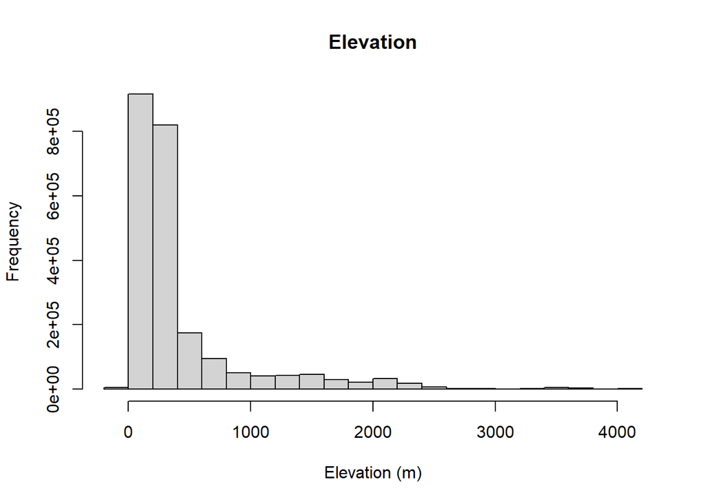

```r
hist(met$elev, main = "Elevation", xlab = "Elevation (m)")
```

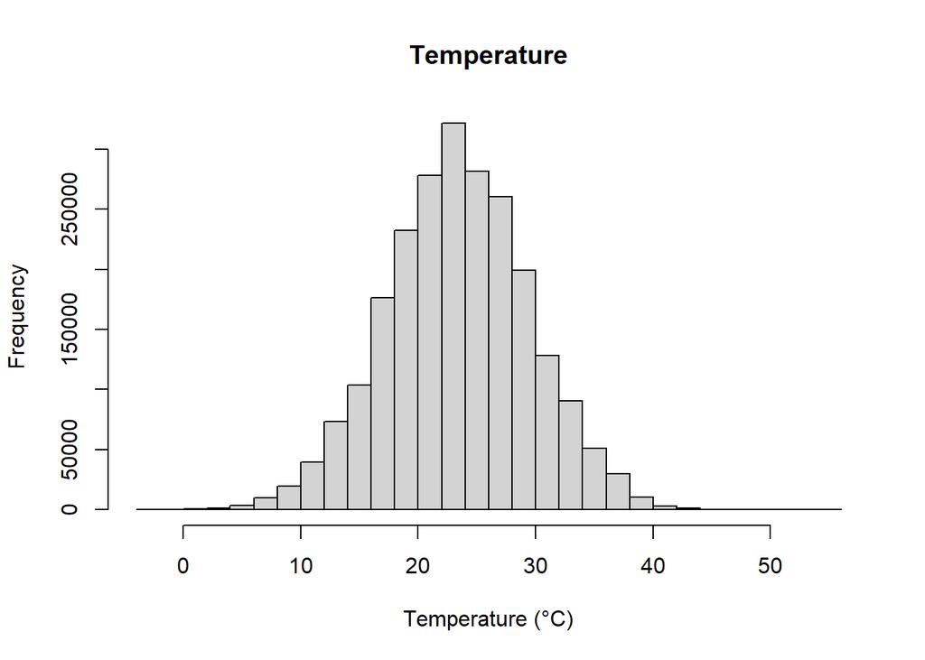

```r
hist(met$temp, main = "Temperature", xlab = "Temperature (°C)")
```

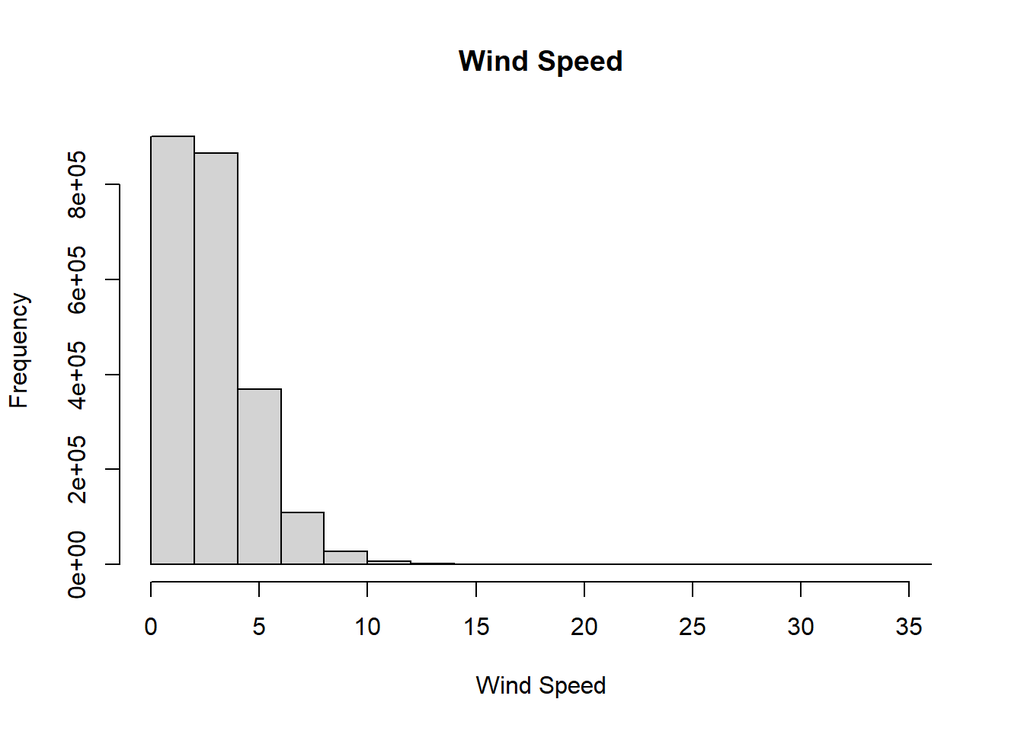

```r
hist(met$wind.sp, main = "Wind Speed", xlab = "Wind Speed")
```

# Look at where the weather station with highest elevation is located.

```r
leaflet(high_station) %>% addProviderTiles("OpenStreetMap") %>% addCircles(lat = ~lat, lng = ~lon, radius = 100, fillOpacity = 1)
```

[interactive chart not shown]

# The highest elevation weather station is located in Colorado in the Rocky Mountains.

# Look at the time series of temperature and wind speed at this location. For this we will need to create a date-time variable for the x-axis.

```r
high_station$date <- with(high_station, ymd_h(paste(year, month, day, hour, sep = " ")))
summary(high_station$date)
```

```
##                  Min.               1st Qu.                Median
## "2019-08-01 00:00:00" "2019-08-08 11:00:00" "2019-08-16 22:00:00"
##                  Mean               3rd Qu.                  Max.
## "2019-08-16 14:09:56" "2019-08-24 11:00:00" "2019-08-31 22:00:00"
##                  NA's
##                 "182"
```

```r
sum(is.na(high_station$date))
```

```
## [1] 182
```

```r
high_station <- high_station[!is.na(high_station$date), ]
high_station <- high_station[order(high_station$date), ]
```

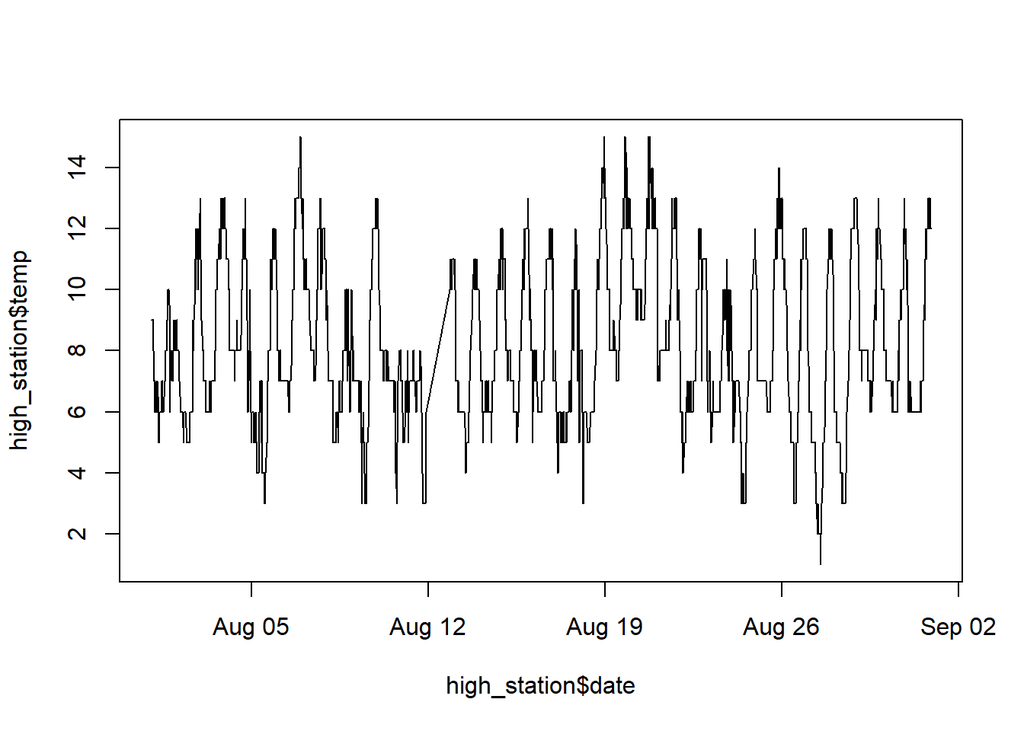

```r
plot(high_station$date, high_station$temp, type = "l")
```

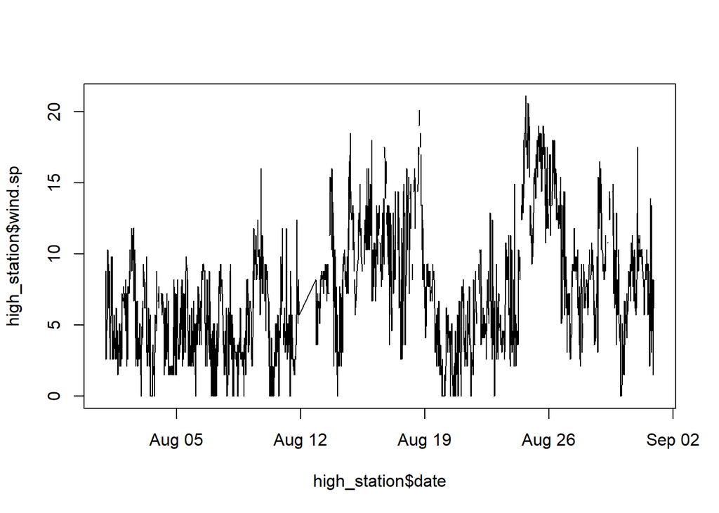

```r
plot(high_station$date, high_station$wind.sp, type = "l")
```

#The time series plot at the highest-elevation weather station shows a consistent daily cycle with regular increases and decreases occurring at approximately 24-hour intervals.The wind speed has variability with episodic spikes and no clear daily cycle.

# Part 8: Ask questions

# A few questions that come to mind are: How strongly are temperature and dew point related? #Does atmospheric pressure decrease with elevation? Is relative humidity higher when temperature is lower?

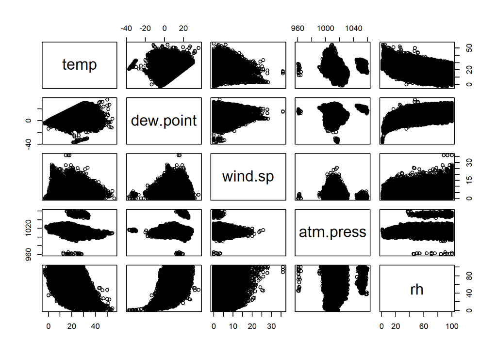

```r
# Pairwise correlations
pairs(met[, c("temp", "dew.point", "wind.sp", "atm.press", "rh")])
```

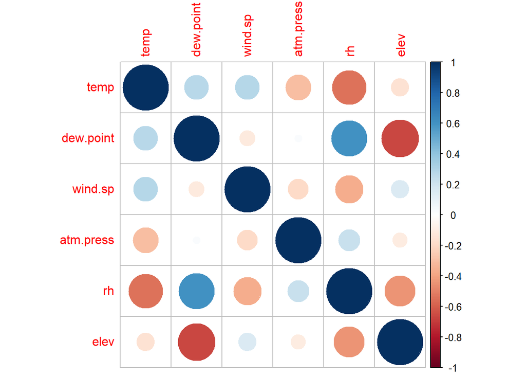

```r
vars <- met[, c("temp", "dew.point", "wind.sp", "atm.press", "rh", "elev")]
corrplot(cor(vars, use = "complete.obs"))
```